# Covid-19 Pandemic Situation in Turkey

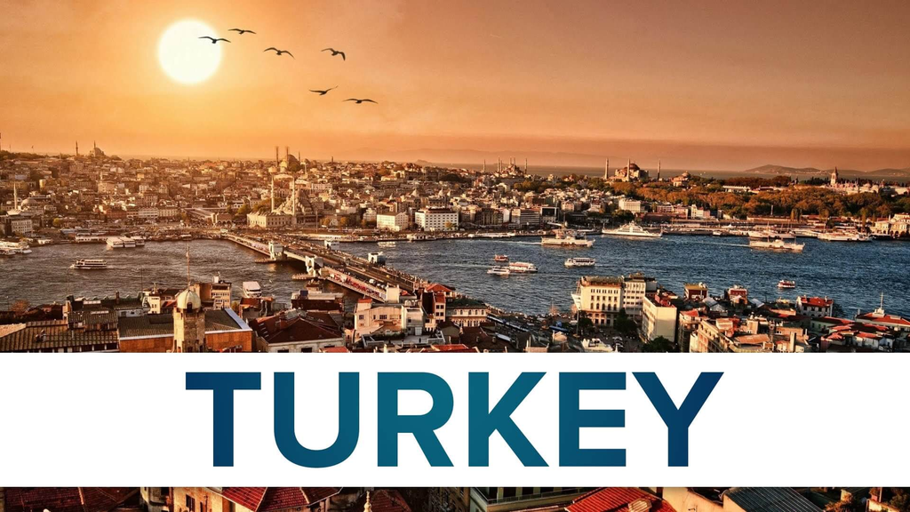

### *Let’s get to know about Turkey*

| Property | Description |
| --- | --- |
| Location | Western Asia |
| Capital City | Ankara (+2 GMT) |
| Chief of State | President Recep Tayyip Erdogan |
| Head of Govt. | President Recep Tayyip Erdogan |
| Currency | Turkish Lira (TRY) |
| Major Languages | Turkish (official), Kurdish other minority languages |
| Primary Religions | Muslim 99.8% (mostly Sunni),other 0.2% (mostly Christians and Jews) |
| Population | 82 million (2019) |

**Strengths**

- Young and educated workforce
- Well developed and flexible manufacturing tissue
- Strategic geopolitical location
- Strong economic recovery after COVID-19 Recovering export performance that reduces current account risks

**Weaknesses**

- Large dependence on external financing Import-dependent structure of the manufacturing sector
- High inflationary pressures resulting from the lira’s weakness
- Weakened central bank reserves, higher public debt
- Increased regional and geopolitical tensions

#### **Location Details**

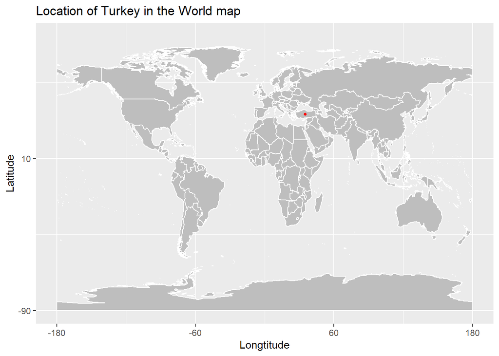

Turkey, a country with a unique status, lies in part in Asia and in part in Europe. Throughout its history it has served as a bridge and a bridge between the two continents. Turkey is located at the crossroads of the Balkans, the Caucasus, the Middle East, and the eastern Mediterranean. It is among the **largest countries in the region geographically and geographically**, and its land area is larger than that of any European empire. Almost the whole country is in Asia, which consists of the southern peninsula of Asia Minor also known as Anatolia (Anadolu) and, to the east, part of the mountainous region sometimes known as the Armenian Highland. The remnant of Turkey’s Trace (Trakya) lies in the southeastern part of Europe, a small remnant of the empire that once stretched over most of the Balkans. The country has a northwestern range from a distance of about 300 to 400 kilometers (480 to 640 kilometers), and from a distance of 1,000 kilometers from west to east. Turkey is bordered north by the Black Sea, northeast by Georgia and Armenia, east by Azerbaijan and Iran, southeast by Iraq and Syria, southwest and west by the Mediterranean Sea and the Aegean Sea, and northwest by Greece and Bulgaria. The capital city is Ankara, and the largest city with its largest harbor is Istanbul. The country has a northwestern range from a distance of about 300 to 400 kilometers (480 to 640 kilometers), and from a distance of 1,000 kilometers from west to east. Turkey is bordered north by the Black Sea, northeast by Georgia and Armenia, east by Azerbaijan and Iran, southeast by Iraq and Syria, southwest and west by the Mediterranean Sea and the Aegean Sea, and northwest by Greece and Bulgaria. The capital city is Ankara, and the largest city with its largest harbor is well known Istanbul.

#### **Climate**

Coastal Regions: The Aegean, Mediterranean, and coastal regions of Turkey reflect the typical Mediterranean climate with hot summers and mild winters, although Istanbul may experience extremely cold temperatures and snow in winter. July and August are the hottest months with the highest humidity in summer.In south, temperatures rise by a few degrees and water temperatures warm up. The swimming season runs from June to September along the shores of Marmara and the North Aegean, and from April to October along the coast of the South Aegean and the Mediterranean.The Black Sea region is temperate. The summer months are warm and the winter months are mild. Rainfall is heavier here than in other regions. The swimming season runs from June to early September, although the weather is very unpredictable. Inland: There are significant differences between the climate of the coastal regions and the rural areas, which are usually located at higher elevations. The climate reaches its peak in Turkey’s Central and Eastern Anatolia regions, with hot and dry summers, and freezing temperatures and winters.In mountainous areas, summer months are difficult and winter months are difficult.

#### **Lockdown Status**

From 6 September, Turkish citizens must have proof of the discovery of two Covid vaccines or the latest Covid rescue (linked to the HES code) or a negative PCR test (within 48 hours) of all domestic air travel, and travel. provincial, including buses, trains or other public transport vehicles. HES (Hayat Eve Sigar) code for domestic and international flights, as well as train and boat travel are also required. In addition, the HES code will be required when looking for accommodation including hotels, motels, residential areas, pensions, camps etc. Some states also require an HES code to enter public buildings, shopping malls, and banks. This does not apply to foreign tourists. This can be done through the e-Devlet program, the ‘Hayat Eve Sıgar’ app and SMS.

#### **Actions taken by government regarding Covid-19**

Turkey has launched a 21-point stimulus package (Economic Stability Shield) worth USD 15.4 billion to deal with the epidemic. In addition, Turkey has promised a “series of measures” related to fiscal policy, including tax evasion and money transfers, as well as debt guarantees and delays in repayment of loans.A three-month deferral of loan payments to affected businesses, accommodation tax will be cancelled until November, social security premiums will be deferred by six months for several sectors and stock financing assistance to importers who are affected by the global pandemic.

**Other**

- Introduced online education system Closed gyms, bars, night clubs and other places of social gatherings to minimize human contact
- Placed pilgrims in quarantine(14 day self quarantine)
- Suspended friday prayers
- Promote work from home for elderly persons
- Imposed a curfew for people aged 65 and over
- Banned flights to/from many countries(about 68) Launched public awareness campaigns

#### **Covid-19 Summary in Turkey**

| Type | Total counts | Average cases per day |
| --- | --- | --- |
| Confirmed Cases | 6794670 | 11212.33 |
| Death Cases | 61140 | 100.8911 |
| Recovered Cases | 5478185 | 9039.909 |

Since the first step of data analysis process is data tidying,I did replace NA values and negative values with zeros, to increase accuracy of my conclusions. Most of recovered cases were not available.

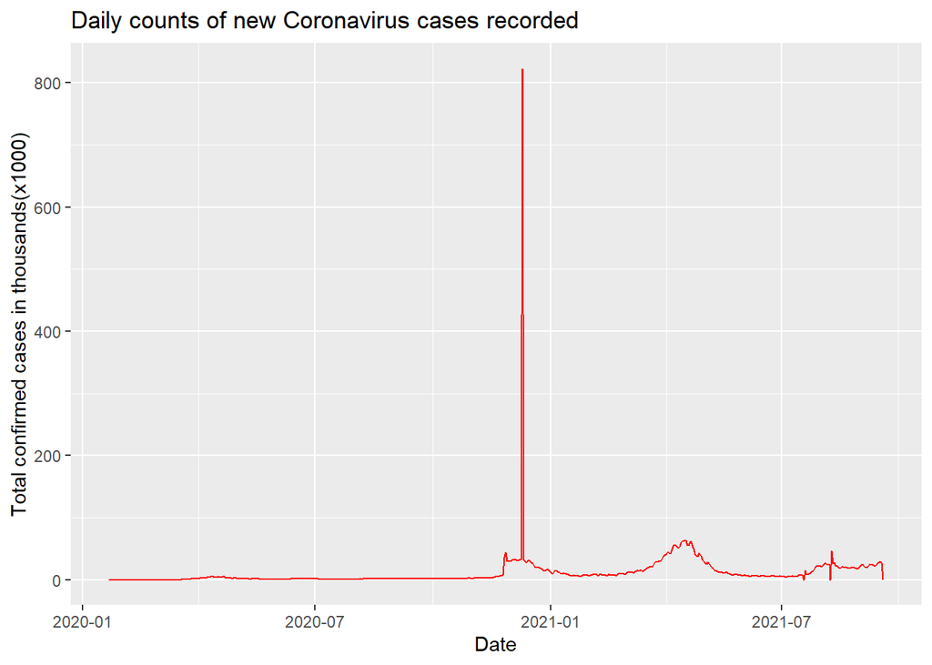

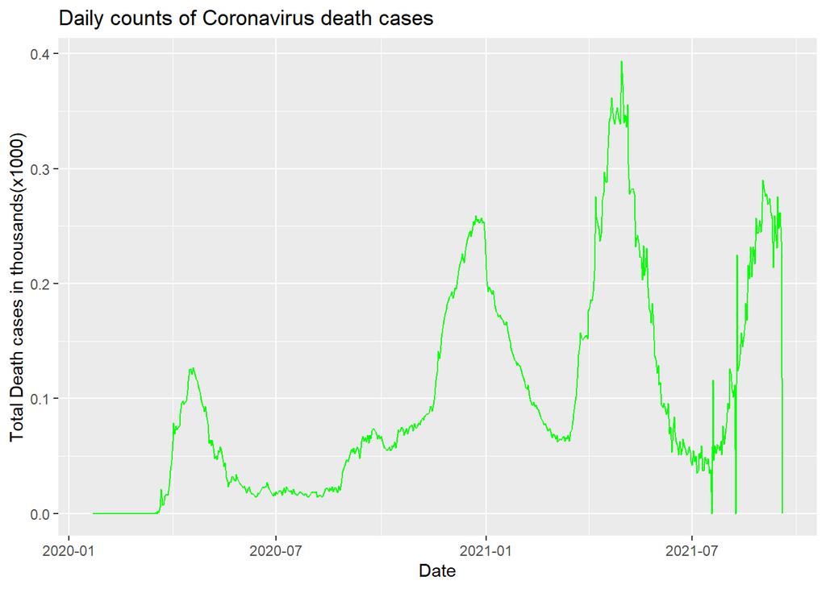

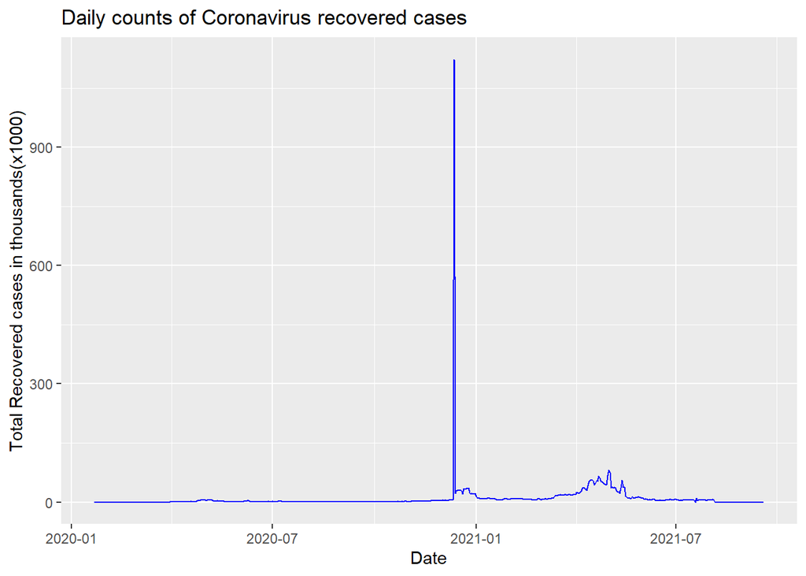

These figures will help us to identify current corona situation in Turkey and as you can see maximum number of both recovered and confirmed cases had occurred in the end of 2020 while death counts were also increasing.

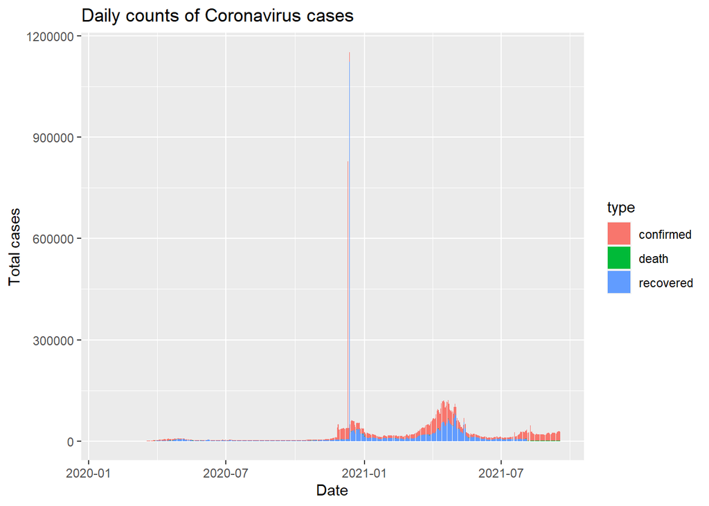

#### **Comparison to the countries with same size of population**

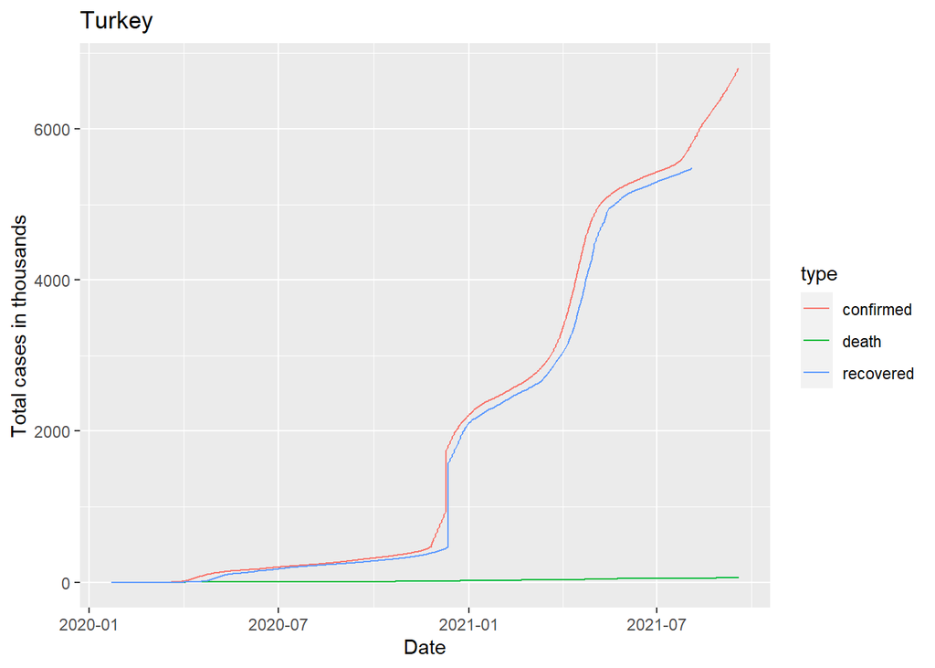

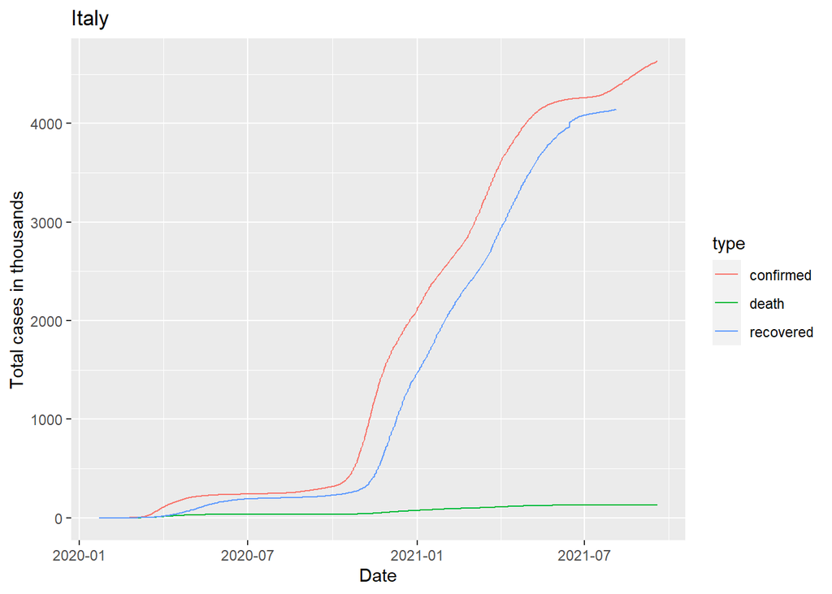

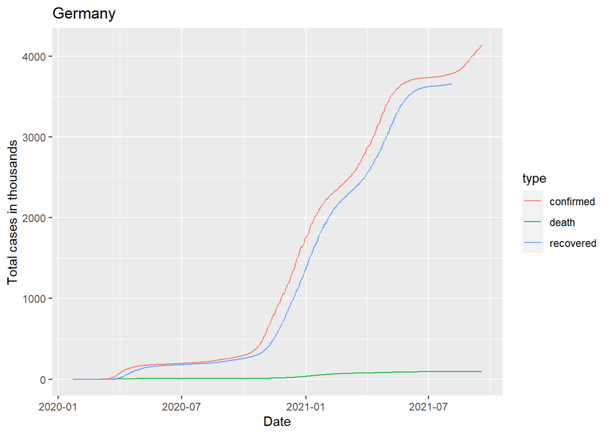

#### **Comparison to the countries with larger population size**

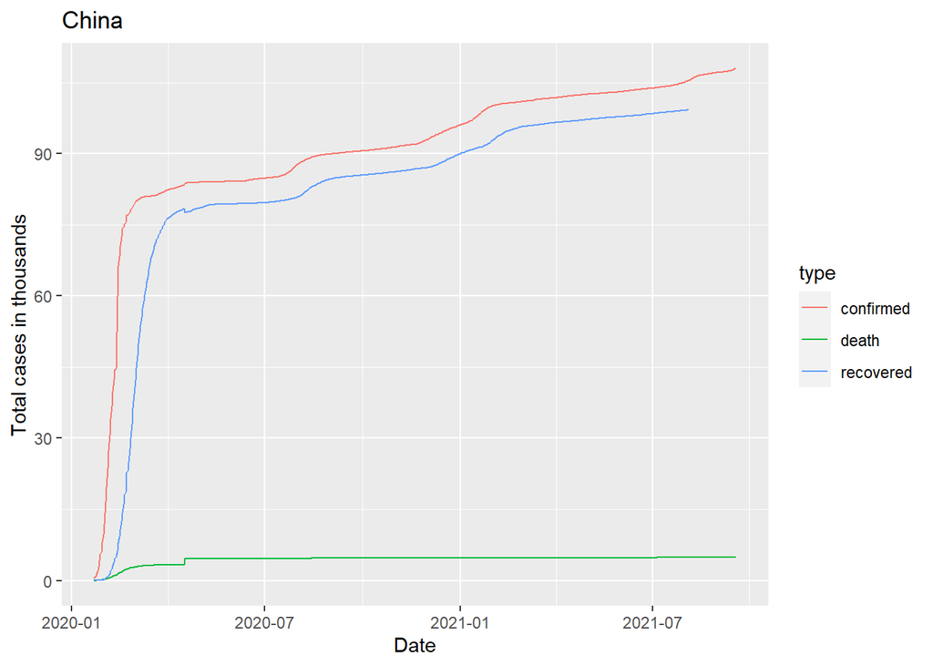

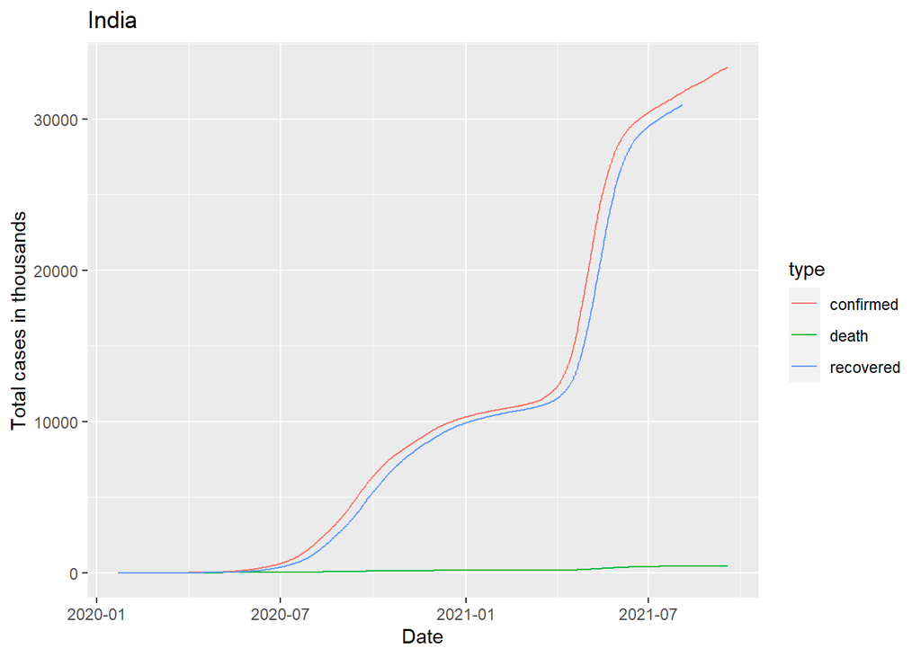

#### **Comparison to the countries with smaller population size**

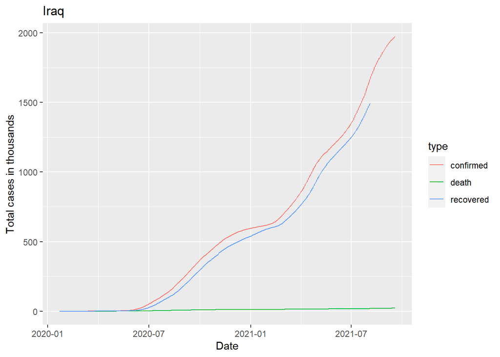

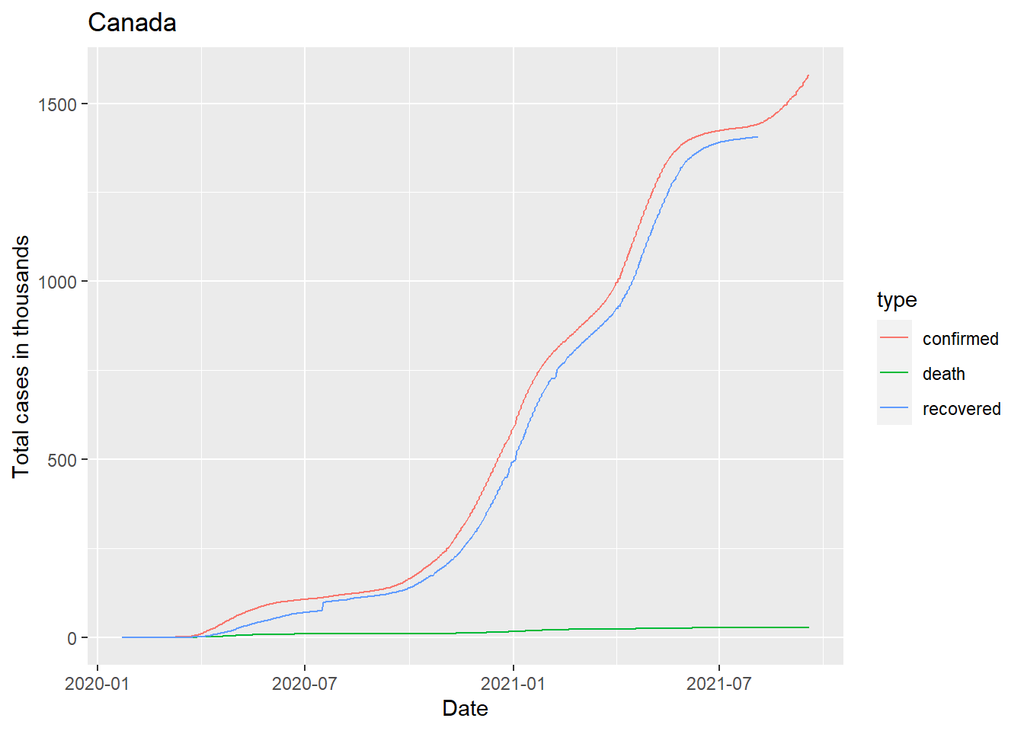

These figures also showing same trend as Turkey.

#### **Death Rate Calculation**

$Death Rate=\frac{Death Count}{Total Population}*100,000$

| Country | Total Population | Death counts | Crude Death rate |
| --- | --- | --- | --- |
| Turkey | 83614362 | 61361 | 73.38572 |
| Germany | 83121363 | 92964 | 111.84128 |
| Italy | 59126079 | 130284 | 220.34947 |
| Iraq | 41190700 | 21775 | 52.86387 |
| Canada | 38418261 | 27434 | 71.40875 |

#### **References**

1. (n.d.). Retrieved from W3 Schools: https://www.w3schools.com/default.asp
2. Grolemund , & Wickham. (n.d.). In R for Data Science (pp. Chapter 3.1-3.6 and Chapter 3.7-3.10).
3. Hannah Ritchie, Edouard Mathieu, Lucas Rodés-Guirao, Cameron Appel, Charlie Giattino, Esteban Ortiz-Ospina, Joe Hasell, Bobbie Macdonald, Diana Beltekian and Max Roser (2020) - “Coronavirus Pandemic (COVID-19)”. Published online at OurWorldInData.org. Retrieved from: ‘https://ourworldindata.org/coronavirus’ [Online Resource]
4. Kaymaz, M., & AL SHARQ FORUM. (09 April 2020). How is Turkey Responding to the Covid-19 Pandemic?
5. Mukherjee, A., Sarkar, K., & Bhadra, A. (2021). Impact of population density on Covid-19 6. infected and mortality rate in India. Modeling Earth Systems and Environment , pages623–629 .
6. Yapp, M. E. (2000). Turkey. Britannica.
7. [https://www.climatestotravel.com/climate/turkey]